# Regression and Volleyball - 2

Jessi Kehe

This R Markdown document was adapted from documents created by Professor Bret Larget.

### Setup details

# Lecture: Volleyball and Cleaning Data

### Data

- Use the data file created previously
- Also use a new file with data from each individual match

```r
vb_team <- read_csv("../../data/volleyball-team-2019.csv")
vb_match <- read_csv("../../data/vb-division1-2019-all-matches.csv") %>%
  mutate(index = row_number()) %>%
  select(index,everything())
```

### Cleaning the Match Data

- The *vb_match* data results from scraping the NCAA statistics web site for match results.
- Here is the URL for a sample page with results.
  - [website](https://stats.ncaa.org/season_divisions/16966/scoreboards?utf8=%E2%9C%93&season_division_id=&game_date=08%2F30%2F2019&conference_id=0&tournament_id=&commit=Submit)
- There are a number of potential problems

#### Potential Problems Requiring Cleaning

- When Professor Larget scraped the data, he did not determine the winner (indicated by the color of the background of the team), but instead during processing based on which team won three sets.
  - *But what if there are some matches where this is incorrect, perhaps by forfeit or an error in the source data?*
- The winner of the first four sets is the team that first achieves 25 or more points and has a lead of 2 or more points. Most of the time, a set will finish with a score such as 25-21 or 25-17, but there could be matches with a final score of 27-25, say or something higher, if the match first reaches a tied score of 24-24.
  - *But a set score such as 26-17 is not possible.*
- The fifth set is played to 15, but you need to win by 2 points or more. Anytime a winning fifth set score is greater than 15, the losing score should be exactly 2 points less.
  - *How can we detect all matches with invalid set scores?*
- Matches that end after three sets should not have scores for the 4th and 5th sets.
- Similarly, matches that end in four sets should not have scores for the 5th set.
  - *How often does this happen?*
- We want to be able to connect the match data with the team summaries.
  - *Do the team names match?*
  - *If we total wins and losses, do the numbers match?*

### Cleaning Problems

1. Count the number of wins and losses from the *vb_team* data frame and compare to the number of matches in the *vb_match* data frame. Explain potential causes for differences.

```r
vb_team %>%
  summarize(wins = sum(W),
            losses = sum(L))
```

```
## # A tibble: 1 x 2
##    wins losses
##   <dbl>  <dbl>
## 1  4907   4852
```

```r
nrow(vb_match)
```

```
## [1] 4958
```

```r
# Let's look at one team
team_name <- "Samford"
vb_match %>%
  filter(team1==team_name | team2==team_name)
```

```
## # A tibble: 26 x 20
##    index date       team1 team2 site   s1_1  s1_2  s1_3  s1_4  s1_5 sets_1  s2_1
##    <int> <date>     <chr> <chr> <chr> <dbl> <dbl> <dbl> <dbl> <dbl>  <dbl> <dbl>
##  1   155 2019-08-30 Samf… Appa… @Tuc…    22    25    21    25    13      2    25
##  2   367 2019-08-31 Samf… Ariz… <NA>     25    18    25    18    15      3    22
##  3   751 2019-09-06 Nort… Samf… <NA>     15    20    14    NA    NA      0    25
##  4   778 2019-09-07 Jack… Samf… <NA>     22    17    19    NA    NA      0    25
##  5   960 2019-09-07 UAB   Samf… <NA>     14    23    25    21    NA      1    25
##  6  1215 2019-09-13 Samf… Kenn… <NA>     21    25    25    21    15      3    25
##  7  1347 2019-09-14 Sout… Samf… @Ken…    18    23    25    20    NA      1    25
##  8  1657 2019-09-20 Samf… Tulsa @Bow…    25    19    25    16    NA      1    27
##  9  1824 2019-09-21 Nort… Samf… @Bow…    25    25    28    NA    NA      3    20
## 10  1945 2019-09-21 Samf… West… <NA>     18    22    16    NA    NA      0    25
## # … with 16 more rows, and 8 more variables: s2_2 <dbl>, s2_3 <dbl>,
## #   s2_4 <dbl>, s2_5 <dbl>, sets_2 <dbl>, winner <chr>, loser <chr>,
## #   attendance <dbl>
```

```r
vb_team %>%
  filter(Team == team_name)
```

```
## # A tibble: 1 x 19
##   Team  Conference     W     L Win_pct  Sets  Aces Assists `Block Solos`
##   <chr> <chr>      <dbl> <dbl>   <dbl> <dbl> <dbl>   <dbl>         <dbl>
## 1 Samf… SoCon         24     5   0.828   115   179    1402            75
## # … with 10 more variables: `Block Assists` <dbl>, Digs <dbl>, Kills <dbl>,
## #   Errors <dbl>, `Total Attacks` <dbl>, Hit_pct <dbl>, `Opp Kills` <dbl>, `Opp
## #   Errors` <dbl>, `Opp Attacks` <dbl>, Opp_pct <dbl>
```

```r
## https://samfordsports.com/sports/womens-volleyball/schedule/2019
## Samford played after 11/16/19 which were not included in vb_match


# Let's look at one team
team_name <- "Akron"
vb_match %>%
  filter(team1==team_name | team2==team_name)
```

```
## # A tibble: 27 x 20
##    index date       team1 team2 site   s1_1  s1_2  s1_3  s1_4  s1_5 sets_1  s2_1
##    <int> <date>     <chr> <chr> <chr> <dbl> <dbl> <dbl> <dbl> <dbl>  <dbl> <dbl>
##  1    19 2019-08-30 Akron San … @For…    20    19    18    NA    NA      0    25
##  2   166 2019-08-30 Akron FGCU  <NA>     18    26    19    14    NA      1    26
##  3   378 2019-08-31 Brya… Akron @For…    25    20    22    16    NA      1    16
##  4   535 2019-09-06 Will… Akron @Cin…    25    28    25    NA    NA      3    16
##  5   696 2019-09-06 Akron Xavi… <NA>     23    15    25    27    15      3    25
##  6   866 2019-09-07 Akron Wrig… @Cin…    18    13    19    NA    NA      0    25
##  7  1226 2019-09-13 Sain… Akron <NA>     13    11    15    NA    NA      0    25
##  8  1353 2019-09-14 East… Akron <NA>     16    14    22    NA    NA      0    25
##  9  1475 2019-09-14 Seto… Akron <NA>     19    20    22    NA    NA      0    25
## 10  1611 2019-09-20 Akron Nort… <NA>     25    25    25    NA    NA      3    14
## # … with 17 more rows, and 8 more variables: s2_2 <dbl>, s2_3 <dbl>,
## #   s2_4 <dbl>, s2_5 <dbl>, sets_2 <dbl>, winner <chr>, loser <chr>,
## #   attendance <dbl>
```

```r
vb_team %>%
  filter(Team == team_name)
```

```
## # A tibble: 1 x 19
##   Team  Conference     W     L Win_pct  Sets  Aces Assists `Block Solos`
##   <chr> <chr>      <dbl> <dbl>   <dbl> <dbl> <dbl>   <dbl>         <dbl>
## 1 Akron MAC           16    12   0.571   103   160    1208            56
## # … with 10 more variables: `Block Assists` <dbl>, Digs <dbl>, Kills <dbl>,
## #   Errors <dbl>, `Total Attacks` <dbl>, Hit_pct <dbl>, `Opp Kills` <dbl>, `Opp
## #   Errors` <dbl>, `Opp Attacks` <dbl>, Opp_pct <dbl>
```

```r
## https://gozips.com/sports/womens-volleyball/schedule/2019
## Akron had one match after 11/16/19






## Can find all teams where there is a mismatch
team_names <- vb_team %>% pull(Team)
n_match <- c()
for(i in 1:length(team_names)){
  team <- team_names[i]
  n_match[i] <- vb_match %>%
  filter(team1==team_name | team2==team_name) %>%
    nrow()
}

vb_team <- vb_team %>%
  mutate(
    n_matches1 = n_match,
    n_matches2 = W+L
  )

vb_team %>%
  filter(n_matches1 != n_matches2)
```

```
## # A tibble: 313 x 21
##    Team  Conference     W     L Win_pct  Sets  Aces Assists `Block Solos`
##    <chr> <chr>      <dbl> <dbl>   <dbl> <dbl> <dbl>   <dbl>         <dbl>
##  1 A&M-… Southland     19    12   0.613   117   184    1421            40
##  2 Abil… Southland      7    19   0.269    93   101     979            24
##  3 Air … Mountain …     8    22   0.267   114   153    1299            34
##  4 Akron MAC           16    12   0.571   103   160    1208            56
##  5 Alab… SEC           12    17   0.414   105   121    1142            68
##  6 Alab… SWAC          18    14   0.562   111   145    1158            78
##  7 Alab… SWAC          17    21   0.447   139   198    1498            98
##  8 Alba… America E…    16    10   0.615    96   139    1060            52
##  9 Alco… SWAC           7    23   0.233   102   153     800            35
## 10 Amer… Patriot       24     7   0.774   115   226    1369            55
## # … with 303 more rows, and 12 more variables: `Block Assists` <dbl>,
## #   Digs <dbl>, Kills <dbl>, Errors <dbl>, `Total Attacks` <dbl>,
## #   Hit_pct <dbl>, `Opp Kills` <dbl>, `Opp Errors` <dbl>, `Opp Attacks` <dbl>,
## #   Opp_pct <dbl>, n_matches1 <int>, n_matches2 <dbl>
```

```r
vb_team %>%
  summarize(total1 = sum(n_matches1),
            total2 = sum(n_matches2))
```

```
## # A tibble: 1 x 2
##   total1 total2
##    <int>  <dbl>
## 1   8964   9759
```

2. Identify all rows in *vb_match* with no winner and loser. Propose a remedy.

```r
vb_match %>%
  filter(is.na(winner) | is.na(loser))
```

```
## # A tibble: 18 x 20
##    index date       team1 team2 site   s1_1  s1_2  s1_3  s1_4  s1_5 sets_1  s2_1
##    <int> <date>     <chr> <chr> <chr> <dbl> <dbl> <dbl> <dbl> <dbl>  <dbl> <dbl>
##  1   360 2019-08-31 Alco… <NA>  @Col…    26    18    21    25    15      3    24
##  2   478 2019-09-03 <NA>  Miss… <NA>     22    15    22    NA    NA      0    25
##  3   503 2019-09-04 <NA>  Gram… <NA>     NA    NA    NA    NA    NA      0    NA
##  4   994 2019-09-10 <NA>  Miss… @Tou…    26    25    24    25    15      3    28
##  5  1029 2019-09-10 Miss… <NA>  <NA>     25    25    25    NA    NA      3    21
##  6  1524 2019-09-17 Gram… <NA>  <NA>     NA    NA    NA    NA    NA      3    NA
##  7  2002 2019-09-23 <NA>  Miss… <NA>     12    21    20    NA    NA      0    25
##  8  2015 2019-09-24 Sain… Lafa… <NA>      0     0     0    NA    NA      0     1
##  9  2016 2019-09-24 <NA>  Gram… <NA>     17    22    17    NA    NA      0    25
## 10  2071 2019-09-26 <NA>  Cali… <NA>     14    11    12    NA    NA      0    25
## 11  2358 2019-10-01 <NA>  Alco… <NA>     25    26    25    NA    NA      3    15
## 12  2387 2019-10-03 <NA>  Ark.… <NA>     17    22    18    NA    NA      0    25
## 13  2388 2019-10-03 <NA>  Ark.… <NA>     20    21    15    NA    NA      0    25
## 14  2821 2019-10-11 <NA>  Gram… <NA>     24    21    14    NA    NA      0    26
## 15  3043 2019-10-16 <NA>  Prai… <NA>     16    25    25    23    11      2    25
## 16  3346 2019-10-22 Prai… <NA>  <NA>     NA    NA    NA    NA    NA      0    NA
## 17  3688 2019-10-29 Alco… <NA>  <NA>     25    22    25    25    NA      3    22
## 18  3721 2019-10-31 Gram… <NA>  <NA>     NA    NA    NA    NA    NA      3    NA
## # … with 8 more variables: s2_2 <dbl>, s2_3 <dbl>, s2_4 <dbl>, s2_5 <dbl>,
## #   sets_2 <dbl>, winner <chr>, loser <chr>, attendance <dbl>
```

It appears that cases where a winner or loser is not listed is also missing the second team, except for index = 2015 (Saint Peter’s vs. Lafayette); however, the points are not accurate and neither team is listed as the winner or loser. It seems this match may not have taken place.

When looking at the match data online, it appears Grambling beat Jarvis Christian on 9/24/19, but the information was not scraped.

We could look online to find all the missing information to update the missing teams.

3. Identify all matches in *vb_match* with invalid set scores.

```r
## Check that final scores of 15 won by at least 2 points in set 5
vb_match %>%
  filter(!is.na(s1_5) & !is.na(s2_5)) %>%
  filter( (s1_5 == 15 & s2_5 <= 15 & s1_5-s2_5 <2) | (s2_5 == 15 & s1_5 <= 15 & s2_5-s1_5<2))
```

```
## # A tibble: 0 x 20
## # … with 20 variables: index <int>, date <date>, team1 <chr>, team2 <chr>,
## #   site <chr>, s1_1 <dbl>, s1_2 <dbl>, s1_3 <dbl>, s1_4 <dbl>, s1_5 <dbl>,
## #   sets_1 <dbl>, s2_1 <dbl>, s2_2 <dbl>, s2_3 <dbl>, s2_4 <dbl>, s2_5 <dbl>,
## #   sets_2 <dbl>, winner <chr>, loser <chr>, attendance <dbl>
```

```r
## Check that final scores of > 15 won by 2 points in set 5
vb_match %>%
  filter(!is.na(s1_5) & !is.na(s2_5)) %>%
  filter( (s1_5 > 15 | s2_5 > 15) & (abs(s1_5-s2_5) != 2)) %>%
  select(index, s1_5, s2_5)
```

```
## # A tibble: 3 x 3
##   index  s1_5  s2_5
##   <int> <dbl> <dbl>
## 1   343    13    17
## 2   453    16    12
## 3  2367    16    13
```

```r
## Check that final scores of 25 won by at least 2 points in sets 1-4
check_set <- function(s1_x, s2_x){
  s1_x <- enquo(s1_x)
  s2_x <- enquo(s2_x)
  vb_match %>%
  filter(!is.na(!!s1_x) & !is.na(!!s2_x)) %>%
  filter( (!!s1_x == 25 & !!s2_x <= 25 & !!s1_x-!!s2_x <2) | (!!s2_x == 25 & !!s1_x <= 25 & !!s2_x-!!s1_x<2))
}

check_set(s1_1,s2_1)
```

```
## # A tibble: 0 x 20
## # … with 20 variables: index <int>, date <date>, team1 <chr>, team2 <chr>,
## #   site <chr>, s1_1 <dbl>, s1_2 <dbl>, s1_3 <dbl>, s1_4 <dbl>, s1_5 <dbl>,
## #   sets_1 <dbl>, s2_1 <dbl>, s2_2 <dbl>, s2_3 <dbl>, s2_4 <dbl>, s2_5 <dbl>,
## #   sets_2 <dbl>, winner <chr>, loser <chr>, attendance <dbl>
```

```r
check_set(s1_2,s2_2)
```

```
## # A tibble: 0 x 20
## # … with 20 variables: index <int>, date <date>, team1 <chr>, team2 <chr>,
## #   site <chr>, s1_1 <dbl>, s1_2 <dbl>, s1_3 <dbl>, s1_4 <dbl>, s1_5 <dbl>,
## #   sets_1 <dbl>, s2_1 <dbl>, s2_2 <dbl>, s2_3 <dbl>, s2_4 <dbl>, s2_5 <dbl>,
## #   sets_2 <dbl>, winner <chr>, loser <chr>, attendance <dbl>
```

```r
check_set(s1_3,s2_3)
```

```
## # A tibble: 1 x 20
##   index date       team1 team2 site   s1_1  s1_2  s1_3  s1_4  s1_5 sets_1  s2_1
##   <int> <date>     <chr> <chr> <chr> <dbl> <dbl> <dbl> <dbl> <dbl>  <dbl> <dbl>
## 1  1662 2019-09-20 Sout… Tole… @Mem…    25    17    25    25    NA      3    22
## # … with 8 more variables: s2_2 <dbl>, s2_3 <dbl>, s2_4 <dbl>, s2_5 <dbl>,
## #   sets_2 <dbl>, winner <chr>, loser <chr>, attendance <dbl>
```

```r
check_set(s1_4,s2_4)
```

```
## # A tibble: 1 x 20
##   index date       team1 team2 site   s1_1  s1_2  s1_3  s1_4  s1_5 sets_1  s2_1
##   <int> <date>     <chr> <chr> <chr> <dbl> <dbl> <dbl> <dbl> <dbl>  <dbl> <dbl>
## 1   482 2019-09-03 Lime… USC … <NA>     25    14    20    25    15      3    15
## # … with 8 more variables: s2_2 <dbl>, s2_3 <dbl>, s2_4 <dbl>, s2_5 <dbl>,
## #   sets_2 <dbl>, winner <chr>, loser <chr>, attendance <dbl>
```

```r
## Check that final scores of > 25 won by 2 points in sets 1-4
check_set2 <- function(s1_x, s2_x){
  s1_x <- enquo(s1_x)
  s2_x <- enquo(s2_x)
  vb_match %>%
  filter(!is.na(!!s1_x) & !is.na(!!s2_x)) %>%
  filter( (!!s1_x > 25 | !!s2_x > 25) & (abs(!!s1_x-!!s2_x) != 2)) %>%
  select(index, !!s1_x, !!s2_x)
}

check_set2(s1_1,s2_1)
```

```
## # A tibble: 9 x 3
##   index  s1_1  s2_1
##   <int> <dbl> <dbl>
## 1   161    26    22
## 2   166    18    26
## 3   471    26    15
## 4  1333    26    18
## 5  1403    26    16
## 6  1441    26    23
## 7  1782    22    26
## 8  1851    26    19
## 9  1871    28    28
```

```r
check_set2(s1_2,s2_2)
```

```
## # A tibble: 9 x 3
##   index  s1_2  s2_2
##   <int> <dbl> <dbl>
## 1    21    26    14
## 2    62    26    18
## 3    82    16    27
## 4   139    20    27
## 5   311    19    26
## 6   464    26    14
## 7   604    15    26
## 8   926    26    29
## 9  4921    26    22
```

```r
check_set2(s1_3,s2_3)
```

```
## # A tibble: 6 x 3
##   index  s1_3  s2_3
##   <int> <dbl> <dbl>
## 1    89    13    26
## 2   538    22    32
## 3   833    29    15
## 4   939    26     7
## 5  1632    28    31
## 6  1804    22    26
```

```r
check_set2(s1_4,s2_4)
```

```
## # A tibble: 9 x 3
##   index  s1_4  s2_4
##   <int> <dbl> <dbl>
## 1   378    16    26
## 2   434    26    23
## 3   463    18    27
## 4   742    40    43
## 5  1215    21    41
## 6  1782    22    26
## 7  1884    26    13
## 8  2115    23    26
## 9  3005    26    19
```

There appears to be quite a few scores that do not follow the rules.

# Lecture: Logistic Model

### Data

- The data modeled are the scores for each set across the individidual matches between division I opponents during the 2019 women’s volleyball season.

### Model

- The model we will consider is where the strength of each team is represented by a parameter $\theta$. The difference between the values of this parameter for two opponents (possibly with adjustments for home court and random effects) determine the chance that a team wins a point.
- Assume that a match is made up of a series of independent Bernoulli trials, each resulting in a point for one team or the other, until the match is won.
  - A Bernoulli trial is a Binomial distribution with n = 1
  - If X ~ Bernoulli(p), the P(X = 1) = p and P(X = 0) = 1 - p
- This model assumes the chance of a team winning a point is the same whether or not the team is serving and assumes that the chance does not depend on the current score of the game.
  - These assumptions cannot be checked using only data from the scores of each set from each match

The simple model for the probability that team $i$ with strength $\theta_i$ wins a single point versus team_2 with strength $\theta_j$ is a function of
$$\Delta_{ij} = \theta_i - \theta_j$$
where the probability is
$$\mathsf{P}(\Delta_{ij}) = \frac{1}{1 + \mathrm{e}^{-\Delta_{ij}}}$$
- Note that this probability is equal to $\frac{\mathrm{e}^{\Delta_{ij}}}{1 + \mathrm{e}^{\Delta_{ij}}}$ and that the probability that team $j$ wins the point is one minus this probablity, or $\frac{1}{1 + \mathrm{e}^{\Delta_{ij}}}$.

- For more complicated models that also depend on a home-court advantage and a match random effect, replace $\Delta_{ij}$ with $\Delta_{ij} + \alpha_{ijk} + \beta_k$
  - $\alpha_{ijk}$ is equal to $\alpha$ if team $i$ is home in match $k$, $-\alpha$ if team $j$ is home during match $k$ and 0 if match $k$ is at a neutral site.
  - The match random effect $\beta_k$ is assumed to be drawn from a normal mean zero distribution.
- The simple model is an example of a logistic regression model and the complicated model is an example of a mixed effects logistic regression model.
- Notice that the model requires a constraint on the values of $\theta_i$ because adding or subtracting the same value to all $\theta$ does not change the point probabilities.
  - In a maximum likelihood setting, this can be accomplished by restricting the sum (or mean) of the $\theta_i$ values to be fixed.
  - (A Bayesian approach might put a prior density on the values with mean zero and an unknown standard deviation.)

#### The Inverse-Logistic Function

- The logistic function is a function of the log odds, $\ln(p/(1-p))$, where $p$ is a probability.
  - That is, $\ln(p/(1-p)) = \Delta_{ij}$.
  - If we solve for $p$ we get the inverse-logistic function…
- The inverse of this function is how we model the probability:
  $$p = \frac{1}{1 + \mathrm{e}^{-\Delta_{ij}}}.$$

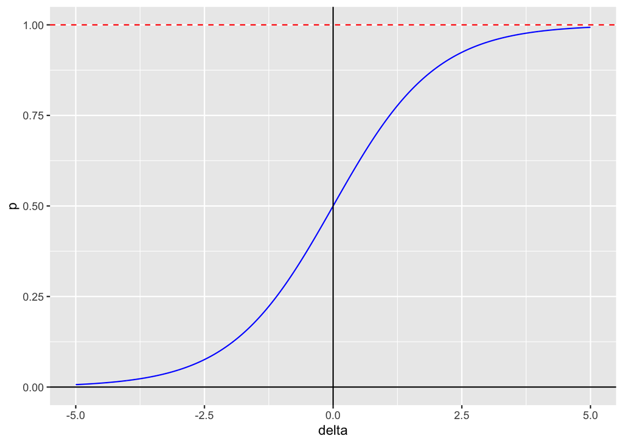

```r
inv_logistic <- function(x) { return ( 1/(1 + exp(-x)) )}
delta <- seq(-5,5,length.out=1001)
p <- inv_logistic(delta)
df <- tibble(delta,p)

ggplot(df, aes(x=delta,y=p)) +
  geom_line(color="blue") +
  geom_hline(yintercept = 0) +
  geom_vline(xintercept = 0) +
  geom_hline(yintercept = 1, color="red", linetype = "dashed")
```

# Lecture: Logistic Model Estimation

### Likelihood

Here are results of one volleyball match.

| teams | 1 | 2 | 3 | 4 | sets |
| --- | --- | --- | --- | --- | --- |
| Northeastern | 16 | 28 | 25 | 23 | 1 |
| Green Bay | 25 | 26 | 27 | 25 | 3 |

This match had a total of 195 points of which team 1, Northeastern, won 92 and team 2, Green Bay, won 103.

The likelihood of this result is
$$L(\Delta) = \mathsf{P}(\Delta)^{92}(1 - \mathsf{P}(\Delta))^{103}$$
which achieves its maximum value when $\mathsf{P}(\Delta) = \frac{92}{195}$, or

$$\Delta = \ln \left( \frac{92/195}{103/195}\right) =
\ln \left( \frac{92}{103}\right) = -0.1129$$

Estimation with many matches is much more complicated, even in the simple model, because the same teams play multiple games against different opponents.

### Simulation

One nice aspect of working in a computational environment like R Studio is that we can run simulations!

Below is code that simulates the outcome of volleyball matches given an input `delta` (i.e., $\Delta$).

```r
inv_logistic <- function(x) { return ( 1/(1 + exp(-x)) )}

sim_set <- function(delta,target)
{
  p <- inv_logistic(delta)
  points <- c(0,0)
  repeat
  {
    pt <- rbinom(1,1,p)
    if ( pt == 1 )
      points[1] <- points[1] + 1
    else
      points[2] <- points[2] + 1
    if ( max(points) >= target && abs(diff(points)) >= 2 )
      break
  }
  return ( points )
}

sim_set(.1, 25)
```

```
## [1] 25 14
```

```r
sim_match <- function(delta)
{
  tab <- matrix(NA,2,5)
  sets <- c(0,0)
  index <- 1
  repeat
  {
    if ( sum(sets) < 4 )
      result <- sim_set(delta,25)
    else
      result <- sim_set(delta,15)
    if ( result[1] > result[2] )
      sets[1] <- sets[1] + 1
    else
      sets[2] <- sets[2] + 1
    tab[,index] <- result
    index <- index + 1
    if ( max(sets == 3) )
      break
  }
  return ( tab )
}
```

Let’s try running several matches.

```r
set.seed(356346)

for ( i in 1:10 )
{
  print(i)
  print( sim_match(0.1) )
}
```

```
## [1] 1
##      [,1] [,2] [,3] [,4] [,5]
## [1,]   25   21   25   23   15
## [2,]   13   25   11   25   12
## [1] 2
##      [,1] [,2] [,3] [,4] [,5]
## [1,]   25   25   25   NA   NA
## [2,]   20   13   19   NA   NA
## [1] 3
##      [,1] [,2] [,3] [,4] [,5]
## [1,]   25   19   25   25   NA
## [2,]   13   25   16   14   NA
## [1] 4
##      [,1] [,2] [,3] [,4] [,5]
## [1,]   25   25   25   NA   NA
```

[output cut: 25 more lines]